# data science project

```python
import pandas as pd
import numpy as np
import matplotlib.pyplot as plt
import seaborn as sns
%matplotlib inline
from scipy import stats
```

Store - the store number

Date - the week of sales

Weekly_Sales - sales for the given store

Holiday_Flag - whether the week is a special holiday week 1 – Holiday week 0 – Non-holiday week

Temperature - Temperature on the day of sale

Fuel_Price - Cost of fuel in the region

CPI – Prevailing consumer price index

Unemployment - Prevailing unemployment rate

Super Bowl: 12-Feb-10, 11-Feb-11, 10-Feb-12, 8-Feb-13 Labour Day: 10-Sep-10, 9-Sep-11, 7-Sep-12, 6-Sep-13 Thanksgiving: 26-Nov-10, 25-Nov-11, 23-Nov-12, 29-Nov-13 Christmas: 31-Dec-10, 30-Dec-11, 28-Dec-12, 27-Dec-13

basic statistic tasks

Which store has maximum sales

Which store has maximum standard deviation i.e., the sales vary a lot. Also, find out the coefficient of mean to standard deviation

Which store/s has good quarterly growth rate in Q3’2012

Some holidays have a negative impact on sales. Find out holidays which have higher sales than the mean sales in non-holiday season for all stores together

Provide a monthly and semester view of sales in units and give insights

```python
df=pd.read_csv(r'C:\Users\venkat\OneDrive\Documents\Walmart_store_sales.csv')
df.head()
```

|  | Store | Date | Weekly_Sales | Holiday_Flag | Temperature | Fuel_Price | CPI | Unemployment |
| --- | --- | --- | --- | --- | --- | --- | --- | --- |
| 0 | 1 | 05-02-2010 | 1643690.90 | 0 | 42.31 | 2.572 | 211.096358 | 8.106 |
| 1 | 1 | 12-02-2010 | 1641957.44 | 1 | 38.51 | 2.548 | 211.242170 | 8.106 |
| 2 | 1 | 19-02-2010 | 1611968.17 | 0 | 39.93 | 2.514 | 211.289143 | 8.106 |
| 3 | 1 | 26-02-2010 | 1409727.59 | 0 | 46.63 | 2.561 | 211.319643 | 8.106 |
| 4 | 1 | 05-03-2010 | 1554806.68 | 0 | 46.50 | 2.625 | 211.350143 | 8.106 |

```python
#store has maximum values
df.info()
```

[output not shown]

```python
df.describe()
```

|  | Store | Weekly_Sales | Holiday_Flag | Temperature | Fuel_Price | CPI | Unemployment |
| --- | --- | --- | --- | --- | --- | --- | --- |
| count | 6435.000000 | 6.435000e+03 | 6435.000000 | 6435.000000 | 6435.000000 | 6435.000000 | 6435.000000 |
| mean | 23.000000 | 1.046965e+06 | 0.069930 | 60.663782 | 3.358607 | 171.578394 | 7.999151 |
| std | 12.988182 | 5.643666e+05 | 0.255049 | 18.444933 | 0.459020 | 39.356712 | 1.875885 |
| min | 1.000000 | 2.099862e+05 | 0.000000 | -2.060000 | 2.472000 | 126.064000 | 3.879000 |
| 25% | 12.000000 | 5.533501e+05 | 0.000000 | 47.460000 | 2.933000 | 131.735000 | 6.891000 |
| 50% | 23.000000 | 9.607460e+05 | 0.000000 | 62.670000 | 3.445000 | 182.616521 | 7.874000 |
| 75% | 34.000000 | 1.420159e+06 | 0.000000 | 74.940000 | 3.735000 | 212.743293 | 8.622000 |
| max | 45.000000 | 3.818686e+06 | 1.000000 | 100.140000 | 4.468000 | 227.232807 | 14.313000 |

```python
df.sort_values(by='Weekly_Sales',ascending=False).groupby('Store').sum('Weekly_Sales')
```

| Store | Weekly_Sales | Holiday_Flag | Temperature | Fuel_Price | CPI | Unemployment |
| --- | --- | --- | --- | --- | --- | --- |
| 1 | 2.224028e+08 | 10 | 9767.87 | 460.417 | 30887.555523 | 1088.290 |
| 2 | 2.753824e+08 | 10 | 9754.94 | 460.417 | 30837.422420 | 1090.210 |
| 3 | 5.758674e+07 | 10 | 10215.09 | 460.417 | 31372.988971 | 1026.309 |
| 4 | 2.995440e+08 | 10 | 8902.23 | 460.027 | 18401.192733 | 852.951 |
| 5 | 4.547569e+07 | 10 | 9925.65 | 460.417 | 30968.878137 | 900.243 |
| 6 | 2.237561e+08 | 10 | 9967.10 | 460.417 | 31110.107182 | 944.787 |
| 7 | 8.159828e+07 | 10 | 5680.00 | 463.543 | 27693.986741 | 1227.760 |
| 8 | 1.299512e+08 | 10 | 8939.50 | 460.417 | 31379.780750 | 871.134 |
| 9 | 7.778922e+07 | 10 | 9691.85 | 460.417 | 31406.616557 | 872.283 |
| 10 | 2.716177e+08 | 10 | 10330.49 | 511.357 | 18401.192733 | 1195.904 |
| 11 | 1.939628e+08 | 10 | 10364.75 | 460.417 | 31372.988971 | 1026.309 |
| 12 | 1.442872e+08 | 10 | 10047.58 | 515.718 | 18401.192733 | 1875.657 |
| 13 | 2.865177e+08 | 10 | 7678.69 | 469.919 | 18401.192733 | 1001.261 |
| 14 | 2.889999e+08 | 10 | 8264.11 | 488.718 | 26638.851959 | 1236.771 |
| 15 | 8.913368e+07 | 10 | 7412.24 | 511.696 | 19318.242848 | 1143.464 |
| 16 | 7.425243e+07 | 10 | 6439.30 | 463.543 | 27693.986741 | 926.353 |
| 17 | 1.277821e+08 | 10 | 6633.37 | 469.919 | 18401.192733 | 936.565 |
| 18 | 1.551147e+08 | 10 | 7632.09 | 492.169 | 19318.242848 | 1263.877 |
| 19 | 2.066349e+08 | 10 | 7478.19 | 511.696 | 19318.242848 | 1143.464 |
| 20 | 3.013978e+08 | 10 | 7929.55 | 488.718 | 29892.452680 | 1054.112 |
| 21 | 1.081179e+08 | 10 | 9845.21 | 460.417 | 30837.422420 | 1090.210 |
| 22 | 1.470756e+08 | 10 | 7850.29 | 492.169 | 19878.613542 | 1153.920 |
| 23 | 1.987506e+08 | 10 | 6979.13 | 492.169 | 19318.242848 | 685.830 |
| 24 | 1.940160e+08 | 10 | 7726.29 | 511.696 | 19318.242848 | 1207.923 |
| 25 | 1.010612e+08 | 10 | 7455.79 | 488.718 | 29892.452680 | 1054.112 |
| 26 | 1.434164e+08 | 10 | 6243.13 | 492.169 | 19318.242848 | 1125.706 |
| 27 | 2.538559e+08 | 10 | 8195.49 | 511.696 | 19878.613542 | 1144.250 |
| 28 | 1.892637e+08 | 10 | 10047.58 | 515.718 | 18401.192733 | 1875.657 |
| 29 | 7.714155e+07 | 10 | 7850.29 | 492.169 | 19318.242848 | 1402.313 |
| 30 | 6.271689e+07 | 10 | 9845.21 | 460.417 | 30837.422420 | 1090.210 |
| 31 | 1.996139e+08 | 10 | 9845.21 | 460.417 | 30837.422420 | 1090.210 |
| 32 | 1.668192e+08 | 10 | 7542.90 | 463.543 | 27693.986741 | 1227.760 |
| 33 | 3.716022e+07 | 10 | 10972.13 | 511.357 | 18401.192733 | 1220.241 |
| 34 | 1.382498e+08 | 10 | 8364.91 | 460.027 | 18401.192733 | 1420.677 |
| 35 | 1.315207e+08 | 10 | 8195.49 | 488.718 | 19878.613542 | 1256.766 |
| 36 | 5.341221e+07 | 10 | 10175.93 | 458.201 | 30706.256907 | 1125.274 |
| 37 | 7.420274e+07 | 10 | 10175.93 | 460.417 | 30706.256907 | 1125.274 |
| 38 | 5.515963e+07 | 10 | 10047.58 | 515.718 | 18401.192733 | 1875.657 |
| 39 | 2.074455e+08 | 10 | 10095.42 | 460.417 | 30706.256907 | 1125.274 |
| 40 | 1.378703e+08 | 10 | 6817.46 | 492.169 | 19318.242848 | 685.830 |
| 41 | 1.813419e+08 | 10 | 6922.68 | 463.543 | 27693.986741 | 997.193 |
| 42 | 7.956575e+07 | 10 | 10330.49 | 511.357 | 18401.192733 | 1195.904 |
| 43 | 9.056544e+07 | 10 | 9849.51 | 460.417 | 29706.128216 | 1420.677 |
| 44 | 4.329309e+07 | 10 | 7678.69 | 469.919 | 18401.192733 | 963.194 |
| 45 | 1.123953e+08 | 10 | 8264.11 | 488.718 | 26638.851959 | 1236.771 |

```python
df['Weekly_Sales'].sum().max()
```

```
6737218987.11
```

```python
max_sales=df.groupby('Store')['Weekly_Sales'].sum()
max_sales
```

```
Store
1     2.224028e+08
2     2.753824e+08
3     5.758674e+07
4     2.995440e+08
5     4.547569e+07
6     2.237561e+08
7     8.159828e+07
8     1.299512e+08
9     7.778922e+07
10    2.716177e+08
11    1.939628e+08
12    1.442872e+08
13    2.865177e+08
14    2.889999e+08
```

[output cut: 32 more lines]

```python
max_sales=df.groupby('Store')['Weekly_Sales'].sum()

max_sales.idxmax()
```

```
20
```

[figure not shown]

```python
sns.countplot(y='Weekly_Sales',data=df)
plt.figure(figsize=(10,10))
```

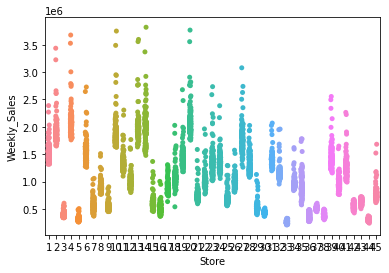

```python
sns.stripplot('Store','Weekly_Sales',data=df)
```

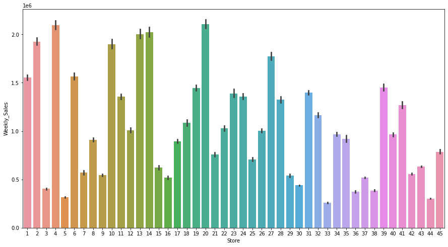

```python
plt.figure(figsize=(15,8))
ax = sns.barplot(x='Store',y='Weekly_Sales',data=df)
```

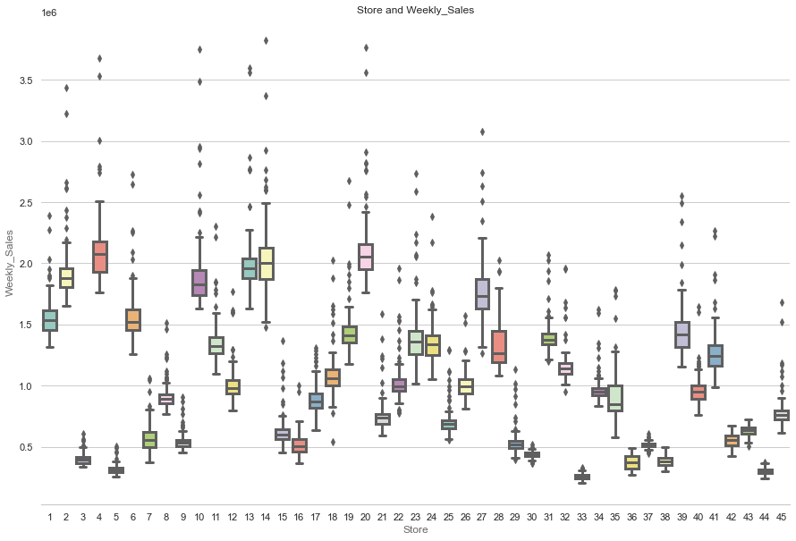

```python
 sns.set(style="whitegrid")
f, ax = plt.subplots(figsize=(15,10))
sns.boxplot(x="Store",y="Weekly_Sales",data=df, palette="Set3", linewidth=3, ax=ax)
sns.despine(left=True)
ax.set_title("Store and Weekly_Sales")
ax.set_xlabel("Store", alpha=0.7)
ax.set_ylabel("Weekly_Sales", alpha=0.7)
```

Which store has maximum standard deviation i.e., the sales vary a lot. Also, find out the coefficient of mean to standard deviation

```python
max_sales=df.groupby('Store')['Weekly_Sales'].std()

max_sales.idxmax()
```

```
14
```

coefficient of variance = std\mean of a column

```python
df.describe()
```

|  | Store | Weekly_Sales | Holiday_Flag | Temperature | Fuel_Price | CPI | Unemployment |
| --- | --- | --- | --- | --- | --- | --- | --- |
| count | 6435.000000 | 6.435000e+03 | 6435.000000 | 6435.000000 | 6435.000000 | 6435.000000 | 6435.000000 |
| mean | 23.000000 | 1.046965e+06 | 0.069930 | 60.663782 | 3.358607 | 171.578394 | 7.999151 |
| std | 12.988182 | 5.643666e+05 | 0.255049 | 18.444933 | 0.459020 | 39.356712 | 1.875885 |
| min | 1.000000 | 2.099862e+05 | 0.000000 | -2.060000 | 2.472000 | 126.064000 | 3.879000 |
| 25% | 12.000000 | 5.533501e+05 | 0.000000 | 47.460000 | 2.933000 | 131.735000 | 6.891000 |
| 50% | 23.000000 | 9.607460e+05 | 0.000000 | 62.670000 | 3.445000 | 182.616521 | 7.874000 |
| 75% | 34.000000 | 1.420159e+06 | 0.000000 | 74.940000 | 3.735000 | 212.743293 | 8.622000 |
| max | 45.000000 | 3.818686e+06 | 1.000000 | 100.140000 | 4.468000 | 227.232807 | 14.313000 |

```python
coefficient_of_variance = 5.643666e+05/1.046965e+06*100
print(coefficient_of_variance,"%")
```

```
53.90501115128012 %
```

```python
df_Store14= df.loc[df['Store']==14]
```

```python
df_Store14
```

|  | Store | Date | Weekly_Sales | Holiday_Flag | Temperature | Fuel_Price | CPI | Unemployment | year | month | semester |
| --- | --- | --- | --- | --- | --- | --- | --- | --- | --- | --- | --- |
| 1859 | 14 | 2010-05-02 | 2623469.95 | 0 | 27.31 | 2.784 | 181.871190 | 8.992 | 2010 | 5 | 1 |
| 1860 | 14 | 2010-12-02 | 1704218.84 | 1 | 27.73 | 2.773 | 181.982317 | 8.992 | 2010 | 12 | 2 |
| 1861 | 14 | 2010-02-19 | 2204556.70 | 0 | 31.27 | 2.745 | 182.034782 | 8.992 | 2010 | 2 | 1 |
| 1862 | 14 | 2010-02-26 | 2095591.63 | 0 | 34.89 | 2.754 | 182.077469 | 8.992 | 2010 | 2 | 1 |
| 1863 | 14 | 2010-05-03 | 2237544.75 | 0 | 37.13 | 2.777 | 182.120157 | 8.992 | 2010 | 5 | 1 |
| ... | ... | ... | ... | ... | ... | ... | ... | ... | ... | ... | ... |
| 1997 | 14 | 2012-09-28 | 1522512.20 | 0 | 64.88 | 3.997 | 192.013558 | 8.684 | 2012 | 9 | 2 |
| 1998 | 14 | 2012-05-10 | 1687592.16 | 0 | 64.89 | 3.985 | 192.170412 | 8.667 | 2012 | 5 | 1 |
| 1999 | 14 | 2012-12-10 | 1639585.61 | 0 | 54.47 | 4.000 | 192.327265 | 8.667 | 2012 | 12 | 2 |
| 2000 | 14 | 2012-10-19 | 1590274.72 | 0 | 56.47 | 3.969 | 192.330854 | 8.667 | 2012 | 10 | 2 |
| 2001 | 14 | 2012-10-26 | 1704357.62 | 0 | 58.85 | 3.882 | 192.308899 | 8.667 | 2012 | 10 | 2 |

143 rows × 11 columns

```python
#coefficient of variance for store 14
df_Store14.describe()
```

|  | Store | Weekly_Sales | Holiday_Flag | Temperature | Fuel_Price | CPI | Unemployment | year | month | semester |
| --- | --- | --- | --- | --- | --- | --- | --- | --- | --- | --- |
| count | 143.0 | 1.430000e+02 | 143.000000 | 143.000000 | 143.000000 | 143.000000 | 143.000000 | 143.000000 | 143.000000 | 143.000000 |
| mean | 14.0 | 2.020978e+06 | 0.069930 | 57.790979 | 3.417608 | 186.285678 | 8.648748 | 2010.965035 | 6.475524 | 1.496503 |
| std | 0.0 | 3.175699e+05 | 0.255926 | 16.271612 | 0.443029 | 3.594820 | 0.151460 | 0.799759 | 3.333213 | 0.501745 |
| min | 14.0 | 1.479515e+06 | 0.000000 | 24.050000 | 2.699000 | 181.646815 | 8.424000 | 2010.000000 | 1.000000 | 1.000000 |
| 25% | 14.0 | 1.873298e+06 | 0.000000 | 45.585000 | 2.921000 | 182.619515 | 8.523000 | 2010.000000 | 4.000000 | 1.000000 |
| 50% | 14.0 | 2.004330e+06 | 0.000000 | 58.850000 | 3.541000 | 185.937438 | 8.625000 | 2011.000000 | 6.000000 | 1.000000 |
| 75% | 14.0 | 2.125780e+06 | 0.000000 | 72.585000 | 3.809000 | 189.924736 | 8.724000 | 2012.000000 | 9.000000 | 2.000000 |
| max | 14.0 | 3.818686e+06 | 1.000000 | 82.990000 | 4.066000 | 192.330854 | 8.992000 | 2012.000000 | 12.000000 | 2.000000 |

```python
#df_store14.describe()
coefficient_of_variance_Store14=3.175699e+05/2.020978e+06*100
print(coefficient_of_variance_Store14,"%")
```

```
15.71367427057593 %
```

Which store/s has good quarterly growth rate in Q3’2012

```python
df.head()
```

|  | Store | Date | Weekly_Sales | Holiday_Flag | Temperature | Fuel_Price | CPI | Unemployment |
| --- | --- | --- | --- | --- | --- | --- | --- | --- |
| 0 | 1 | 05-02-2010 | 1643690.90 | 0 | 42.31 | 2.572 | 211.096358 | 8.106 |
| 1 | 1 | 12-02-2010 | 1641957.44 | 1 | 38.51 | 2.548 | 211.242170 | 8.106 |
| 2 | 1 | 19-02-2010 | 1611968.17 | 0 | 39.93 | 2.514 | 211.289143 | 8.106 |
| 3 | 1 | 26-02-2010 | 1409727.59 | 0 | 46.63 | 2.561 | 211.319643 | 8.106 |
| 4 | 1 | 05-03-2010 | 1554806.68 | 0 | 46.50 | 2.625 | 211.350143 | 8.106 |

```python
df['Date']=pd.to_datetime(df['Date'])
```

[output not shown]

[output cut: 117 more lines]

[output not shown]

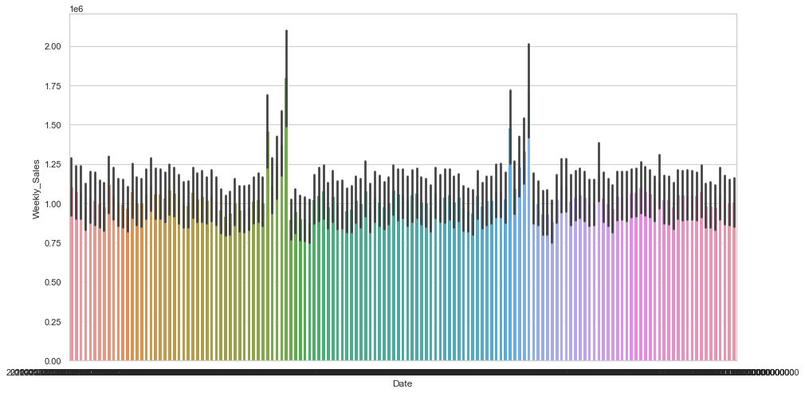

```python
plt.figure(figsize=(15,8))
ax = sns.barplot(x='Date',y='Weekly_Sales',data=df)
```

```python
df['Date'].unique()
```

```
array(['2010-05-02T00:00:00.000000000', '2010-12-02T00:00:00.000000000',
       '2010-02-19T00:00:00.000000000', '2010-02-26T00:00:00.000000000',
       '2010-05-03T00:00:00.000000000', '2010-12-03T00:00:00.000000000',
       '2010-03-19T00:00:00.000000000', '2010-03-26T00:00:00.000000000',
       '2010-02-04T00:00:00.000000000', '2010-09-04T00:00:00.000000000',
       '2010-04-16T00:00:00.000000000', '2010-04-23T00:00:00.000000000',
       '2010-04-30T00:00:00.000000000', '2010-07-05T00:00:00.000000000',
       '2010-05-14T00:00:00.000000000', '2010-05-21T00:00:00.000000000',
       '2010-05-28T00:00:00.000000000', '2010-04-06T00:00:00.000000000',
       '2010-11-06T00:00:00.000000000', '2010-06-18T00:00:00.000000000',
       '2010-06-25T00:00:00.000000000', '2010-02-07T00:00:00.000000000',
       '2010-09-07T00:00:00.000000000', '2010-07-16T00:00:00.000000000',
       '2010-07-23T00:00:00.000000000', '2010-07-30T00:00:00.000000000',
       '2010-06-08T00:00:00.000000000', '2010-08-13T00:00:00.000000000',
       '2010-08-20T00:00:00.000000000', '2010-08-27T00:00:00.000000000',
       '2010-03-09T00:00:00.000000000', '2010-10-09T00:00:00.000000000',
       '2010-09-17T00:00:00.000000000', '2010-09-24T00:00:00.000000000',
       '2010-01-10T00:00:00.000000000', '2010-08-10T00:00:00.000000000',
       '2010-10-15T00:00:00.000000000', '2010-10-22T00:00:00.000000000',
       '2010-10-29T00:00:00.000000000', '2010-05-11T00:00:00.000000000',
       '2010-12-11T00:00:00.000000000', '2010-11-19T00:00:00.000000000',
       '2010-11-26T00:00:00.000000000', '2010-03-12T00:00:00.000000000',
       '2010-10-12T00:00:00.000000000', '2010-12-17T00:00:00.000000000',
       '2010-12-24T00:00:00.000000000', '2010-12-31T00:00:00.000000000',
       '2011-07-01T00:00:00.000000000', '2011-01-14T00:00:00.000000000',
       '2011-01-21T00:00:00.000000000', '2011-01-28T00:00:00.000000000',
       '2011-04-02T00:00:00.000000000', '2011-11-02T00:00:00.000000000',
       '2011-02-18T00:00:00.000000000', '2011-02-25T00:00:00.000000000',
       '2011-04-03T00:00:00.000000000', '2011-11-03T00:00:00.000000000',
       '2011-03-18T00:00:00.000000000', '2011-03-25T00:00:00.000000000',
       '2011-01-04T00:00:00.000000000', '2011-08-04T00:00:00.000000000',
       '2011-04-15T00:00:00.000000000', '2011-04-22T00:00:00.000000000',
       '2011-04-29T00:00:00.000000000', '2011-06-05T00:00:00.000000000',
       '2011-05-13T00:00:00.000000000', '2011-05-20T00:00:00.000000000',
       '2011-05-27T00:00:00.000000000', '2011-03-06T00:00:00.000000000',
       '2011-10-06T00:00:00.000000000', '2011-06-17T00:00:00.000000000',
       '2011-06-24T00:00:00.000000000', '2011-01-07T00:00:00.000000000',
       '2011-08-07T00:00:00.000000000', '2011-07-15T00:00:00.000000000',
       '2011-07-22T00:00:00.000000000', '2011-07-29T00:00:00.000000000',
       '2011-05-08T00:00:00.000000000', '2011-12-08T00:00:00.000000000',
```

[output cut: 17 more lines]

```
       '2012-04-13T00:00:00.000000000', '2012-04-20T00:00:00.000000000',
       '2012-04-27T00:00:00.000000000', '2012-04-05T00:00:00.000000000',
       '2012-11-05T00:00:00.000000000', '2012-05-18T00:00:00.000000000',
       '2012-05-25T00:00:00.000000000', '2012-01-06T00:00:00.000000000',
       '2012-08-06T00:00:00.000000000', '2012-06-15T00:00:00.000000000',
       '2012-06-22T00:00:00.000000000', '2012-06-29T00:00:00.000000000',
       '2012-06-07T00:00:00.000000000', '2012-07-13T00:00:00.000000000',
       '2012-07-20T00:00:00.000000000', '2012-07-27T00:00:00.000000000',
       '2012-03-08T00:00:00.000000000', '2012-10-08T00:00:00.000000000',
       '2012-08-17T00:00:00.000000000', '2012-08-24T00:00:00.000000000',
       '2012-08-31T00:00:00.000000000', '2012-07-09T00:00:00.000000000',
       '2012-09-14T00:00:00.000000000', '2012-09-21T00:00:00.000000000',
       '2012-09-28T00:00:00.000000000', '2012-05-10T00:00:00.000000000',
       '2012-12-10T00:00:00.000000000', '2012-10-19T00:00:00.000000000',
       '2012-10-26T00:00:00.000000000'], dtype='datetime64[ns]')
```

```python
df.Date.dt.strftime('%d-%m-%y').unique()
```

```
array(['02-05-10', '02-12-10', '19-02-10', '26-02-10', '03-05-10',
       '03-12-10', '19-03-10', '26-03-10', '04-02-10', '04-09-10',
       '16-04-10', '23-04-10', '30-04-10', '05-07-10', '14-05-10',
       '21-05-10', '28-05-10', '06-04-10', '06-11-10', '18-06-10',
       '25-06-10', '07-02-10', '07-09-10', '16-07-10', '23-07-10',
       '30-07-10', '08-06-10', '13-08-10', '20-08-10', '27-08-10',
       '09-03-10', '09-10-10', '17-09-10', '24-09-10', '10-01-10',
       '10-08-10', '15-10-10', '22-10-10', '29-10-10', '11-05-10',
       '11-12-10', '19-11-10', '26-11-10', '12-03-10', '12-10-10',
       '17-12-10', '24-12-10', '31-12-10', '01-07-11', '14-01-11',
       '21-01-11', '28-01-11', '02-04-11', '02-11-11', '18-02-11',
       '25-02-11', '03-04-11', '03-11-11', '18-03-11', '25-03-11',
       '04-01-11', '04-08-11', '15-04-11', '22-04-11', '29-04-11',
       '05-06-11', '13-05-11', '20-05-11', '27-05-11', '06-03-11',
       '06-10-11', '17-06-11', '24-06-11', '07-01-11', '07-08-11',
       '15-07-11', '22-07-11', '29-07-11', '08-05-11', '08-12-11',
       '19-08-11', '26-08-11', '09-02-11', '09-09-11', '16-09-11',
       '23-09-11', '30-09-11', '10-07-11', '14-10-11', '21-10-11',
       '28-10-11', '11-04-11', '11-11-11', '18-11-11', '25-11-11',
       '12-02-11', '12-09-11', '16-12-11', '23-12-11', '30-12-11',
       '01-06-12', '13-01-12', '20-01-12', '27-01-12', '02-03-12',
       '02-10-12', '17-02-12', '24-02-12', '03-02-12', '03-09-12',
       '16-03-12', '23-03-12', '30-03-12', '04-06-12', '13-04-12',
       '20-04-12', '27-04-12', '05-04-12', '05-11-12', '18-05-12',
       '25-05-12', '06-01-12', '06-08-12', '15-06-12', '22-06-12',
       '29-06-12', '07-06-12', '13-07-12', '20-07-12', '27-07-12',
       '08-03-12', '08-10-12', '17-08-12', '24-08-12', '31-08-12',
       '09-07-12', '14-09-12', '21-09-12', '28-09-12', '10-05-12',
       '10-12-12', '19-10-12', '26-10-12'], dtype=object)
```

```python
df['year']=pd.DatetimeIndex(df['Date']).year
df['month']=pd.DatetimeIndex(df['Date']).month
```

```python
df.head()
```

|  | Store | Date | Weekly_Sales | Holiday_Flag | Temperature | Fuel_Price | CPI | Unemployment |
| --- | --- | --- | --- | --- | --- | --- | --- | --- |
| 0 | 1 | 2010-05-02 | 1643690.90 | 0 | 42.31 | 2.572 | 211.096358 | 8.106 |
| 1 | 1 | 2010-12-02 | 1641957.44 | 1 | 38.51 | 2.548 | 211.242170 | 8.106 |
| 2 | 1 | 2010-02-19 | 1611968.17 | 0 | 39.93 | 2.514 | 211.289143 | 8.106 |
| 3 | 1 | 2010-02-26 | 1409727.59 | 0 | 46.63 | 2.561 | 211.319643 | 8.106 |
| 4 | 1 | 2010-05-03 | 1554806.68 | 0 | 46.50 | 2.625 | 211.350143 | 8.106 |

```python
df.info()
```

[output not shown]

```python
#change dates into days by creating new variables
day = df.Date.dt.strftime('%d').unique()
day
```

```
array(['02', '19', '26', '03', '04', '16', '23', '30', '05', '14', '21',
       '28', '06', '18', '25', '07', '08', '13', '20', '27', '09', '17',
       '24', '10', '15', '22', '29', '11', '12', '31', '01'], dtype=object)
```

```python
month=df.Date.dt.strftime('%m').unique()
month
year=df.Date.dt.strftime('%y').unique()
year
```

```
array(['10', '11', '12'], dtype=object)
```

```python
df['Date'].dt.month
```

```
0        5
1       12
2        2
3        2
4        5
        ..
6430     9
6431     5
6432    12
6433    10
6434    10
Name: Date, Length: 6435, dtype: int64
```

```python
df_2012=df.loc[df['year']==2012]
df_2012.head()
```

|  | Store | Date | Weekly_Sales | Holiday_Flag | Temperature | Fuel_Price | CPI | Unemployment | year | month | semester |
| --- | --- | --- | --- | --- | --- | --- | --- | --- | --- | --- | --- |
| 100 | 1 | 2012-06-01 | 1550369.92 | 0 | 49.01 | 3.157 | 219.714258 | 7.348 | 2012 | 6 | 1 |
| 101 | 1 | 2012-01-13 | 1459601.17 | 0 | 48.53 | 3.261 | 219.892526 | 7.348 | 2012 | 1 | 1 |
| 102 | 1 | 2012-01-20 | 1394393.84 | 0 | 54.11 | 3.268 | 219.985689 | 7.348 | 2012 | 1 | 1 |
| 103 | 1 | 2012-01-27 | 1319325.59 | 0 | 54.26 | 3.290 | 220.078852 | 7.348 | 2012 | 1 | 1 |
| 104 | 1 | 2012-03-02 | 1636339.65 | 0 | 56.55 | 3.360 | 220.172015 | 7.348 | 2012 | 3 | 1 |

```python
#quarter 1- 1,2,3
#quarter 2- 4,5,6
#quarter 3- 7,8,9
#quarter 4- 10,11,12
```

```python
df_2012_Q3 = df_2012.loc[(df_2012['month']>6)&(df_2012['month']<10)]
```

```python
df_2012_Q3
```

|  | Store | Date | Weekly_Sales | Holiday_Flag | Temperature | Fuel_Price | CPI | Unemployment | year | month | semester |
| --- | --- | --- | --- | --- | --- | --- | --- | --- | --- | --- | --- |
| 109 | 1 | 2012-09-03 | 1675431.16 | 0 | 58.76 | 3.669 | 221.059189 | 7.348 | 2012 | 9 | 2 |
| 122 | 1 | 2012-08-06 | 1697230.96 | 0 | 78.30 | 3.452 | 221.749484 | 7.143 | 2012 | 8 | 2 |
| 127 | 1 | 2012-07-13 | 1527014.04 | 0 | 77.12 | 3.256 | 221.924158 | 6.908 | 2012 | 7 | 2 |
| 128 | 1 | 2012-07-20 | 1497954.76 | 0 | 80.42 | 3.311 | 221.932727 | 6.908 | 2012 | 7 | 2 |
| 129 | 1 | 2012-07-27 | 1439123.71 | 0 | 82.66 | 3.407 | 221.941295 | 6.908 | 2012 | 7 | 2 |
| ... | ... | ... | ... | ... | ... | ... | ... | ... | ... | ... | ... |
| 6426 | 45 | 2012-08-31 | 734297.87 | 0 | 75.09 | 3.867 | 191.461281 | 8.684 | 2012 | 8 | 2 |
| 6427 | 45 | 2012-07-09 | 766512.66 | 1 | 75.70 | 3.911 | 191.577676 | 8.684 | 2012 | 7 | 2 |
| 6428 | 45 | 2012-09-14 | 702238.27 | 0 | 67.87 | 3.948 | 191.699850 | 8.684 | 2012 | 9 | 2 |
| 6429 | 45 | 2012-09-21 | 723086.20 | 0 | 65.32 | 4.038 | 191.856704 | 8.684 | 2012 | 9 | 2 |
| 6430 | 45 | 2012-09-28 | 713173.95 | 0 | 64.88 | 3.997 | 192.013558 | 8.684 | 2012 | 9 | 2 |

540 rows × 11 columns

```python
max_sales_2012Q3= df_2012_Q3.groupby('Store')['Weekly_Sales'].sum()
max_sales_2012Q3
```

```
Store
1     18633209.98
2     22396867.61
3      4966495.93
4     25652119.35
5      3880621.88
6     18341221.11
7      7322393.92
8     10873860.34
9      6528239.56
10    21169356.45
11    16094363.07
12    11777508.50
13    24319994.35
14    20140430.40
```

[output cut: 32 more lines]

```python
max_sales_2012Q3= df_2012_Q3.groupby('Store')['Weekly_Sales'].sum()
max_sales_2012Q3.idxmax()
```

```
4
```

Some holidays have a negative impact on sales. Find out holidays which have higher sales than the mean sales in non-holiday season for all stores together

```python
df.head()
```

|  | Store | Date | Weekly_Sales | Holiday_Flag | Temperature | Fuel_Price | CPI | Unemployment | year | month |
| --- | --- | --- | --- | --- | --- | --- | --- | --- | --- | --- |
| 0 | 1 | 2010-05-02 | 1643690.90 | 0 | 42.31 | 2.572 | 211.096358 | 8.106 | 2010 | 5 |
| 1 | 1 | 2010-12-02 | 1641957.44 | 1 | 38.51 | 2.548 | 211.242170 | 8.106 | 2010 | 12 |
| 2 | 1 | 2010-02-19 | 1611968.17 | 0 | 39.93 | 2.514 | 211.289143 | 8.106 | 2010 | 2 |
| 3 | 1 | 2010-02-26 | 1409727.59 | 0 | 46.63 | 2.561 | 211.319643 | 8.106 | 2010 | 2 |
| 4 | 1 | 2010-05-03 | 1554806.68 | 0 | 46.50 | 2.625 | 211.350143 | 8.106 | 2010 | 5 |

```python
df_wallmart_holiday=df.groupby('Holiday_Flag')
df_holidays=df_wallmart_holiday.get_group(1)
df_nonholidays=df_wallmart_holiday.get_group(0)
mean_nonholiday_sales=df_nonholidays["Weekly_Sales"].mean()
print(mean_nonholiday_sales)
df_holidays[df_holidays['Weekly_Sales']>mean_nonholiday_sales]
```

```
1041256.3802088564
```

|  | Store | Date | Weekly_Sales | Holiday_Flag | Temperature | Fuel_Price | CPI | Unemployment | year | month | semester |
| --- | --- | --- | --- | --- | --- | --- | --- | --- | --- | --- | --- |
| 1 | 1 | 2010-12-02 | 1641957.44 | 1 | 38.51 | 2.548 | 211.242170 | 8.106 | 2010 | 12 | 2 |
| 31 | 1 | 2010-10-09 | 1507460.69 | 1 | 78.69 | 2.565 | 211.495190 | 7.787 | 2010 | 10 | 2 |
| 42 | 1 | 2010-11-26 | 1955624.11 | 1 | 64.52 | 2.735 | 211.748433 | 7.838 | 2010 | 11 | 2 |
| 47 | 1 | 2010-12-31 | 1367320.01 | 1 | 48.43 | 2.943 | 211.404932 | 7.838 | 2010 | 12 | 2 |
| 53 | 1 | 2011-11-02 | 1649614.93 | 1 | 36.39 | 3.022 | 212.936705 | 7.742 | 2011 | 11 | 2 |
| ... | ... | ... | ... | ... | ... | ... | ... | ... | ... | ... | ... |
| 5819 | 41 | 2011-12-30 | 1264014.16 | 1 | 34.12 | 3.119 | 196.358610 | 6.759 | 2011 | 12 | 2 |
| 5825 | 41 | 2012-10-02 | 1238844.56 | 1 | 22.00 | 3.103 | 196.919506 | 6.589 | 2012 | 10 | 2 |
| 5855 | 41 | 2012-07-09 | 1392143.82 | 1 | 67.41 | 3.596 | 198.095048 | 6.432 | 2012 | 7 | 2 |
| 6334 | 45 | 2010-11-26 | 1182500.16 | 1 | 46.15 | 3.039 | 182.783277 | 8.724 | 2010 | 11 | 2 |
| 6386 | 45 | 2011-11-25 | 1170672.94 | 1 | 48.71 | 3.492 | 188.350400 | 8.523 | 2011 | 11 | 2 |

220 rows × 11 columns

```python
df.loc[(df['Holiday_Flag']==0)].Weekly_Sales.mean()#mean of sales when nonholiday
```

```
1041256.3802088564
```

```python
result=df[(df['Weekly_Sales']>1041256.38)&(df['Holiday_Flag']==1)]
#list of holidays where sales. (mean of sales when non holiday)
```

```python
result["Date"].unique
```

```
<bound method Series.unique of 1      2010-12-02
31     2010-10-09
42     2010-11-26
47     2010-12-31
53     2011-11-02
          ...
5819   2011-12-30
5825   2012-10-02
5855   2012-07-09
6334   2010-11-26
6386   2011-11-25
Name: Date, Length: 220, dtype: datetime64[ns]>
```

```python
df.groupby(df.Holiday_Flag).mean()
```

| Holiday_Flag | Store | Weekly_Sales | Temperature | Fuel_Price | CPI | Unemployment | year | month | semester |
| --- | --- | --- | --- | --- | --- | --- | --- | --- | --- |
| 0 | 23.0 | 1.041256e+06 | 61.448124 | 3.368467 | 171.601725 | 7.993514 | 2010.977444 | 6.172932 | 1.458647 |
| 1 | 23.0 | 1.122888e+06 | 50.232044 | 3.227464 | 171.268092 | 8.074127 | 2010.800000 | 10.500000 | 2.000000 |

```python
df.groupby(df.semester).mean()
df.groupby(df.semester).sum()
```

| semester | Store | Weekly_Sales | Holiday_Flag | Temperature | Fuel_Price | CPI | Unemployment | year | month |
| --- | --- | --- | --- | --- | --- | --- | --- | --- | --- |
| 1 | 74520 | 3.327977e+09 | 0 | 188817.75 | 10973.368 | 555623.872665 | 25974.570 | 6515775 | 11745 |
| 2 | 73485 | 3.409242e+09 | 450 | 201553.69 | 10639.267 | 548483.091752 | 25499.967 | 6424785 | 29925 |

```python
df.head()
```

|  | Store | Date | Weekly_Sales | Holiday_Flag | Temperature | Fuel_Price | CPI | Unemployment | year | month | semester |
| --- | --- | --- | --- | --- | --- | --- | --- | --- | --- | --- | --- |
| 0 | 1 | 2010-05-02 | 1643690.90 | 0 | 42.31 | 2.572 | 211.096358 | 8.106 | 2010 | 5 | 1 |
| 1 | 1 | 2010-12-02 | 1641957.44 | 1 | 38.51 | 2.548 | 211.242170 | 8.106 | 2010 | 12 | 2 |
| 2 | 1 | 2010-02-19 | 1611968.17 | 0 | 39.93 | 2.514 | 211.289143 | 8.106 | 2010 | 2 | 1 |
| 3 | 1 | 2010-02-26 | 1409727.59 | 0 | 46.63 | 2.561 | 211.319643 | 8.106 | 2010 | 2 | 1 |
| 4 | 1 | 2010-05-03 | 1554806.68 | 0 | 46.50 | 2.625 | 211.350143 | 8.106 | 2010 | 5 | 1 |

```python
df['semester']= np.where(df['month']<7,1,2)
#for moth 1 to 6 ,semester=1
#for month 7 to 12 ,semester=2
```

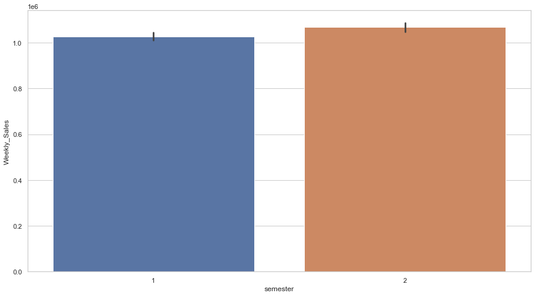

```python
plt.figure(figsize=(15,8))
ax = sns.barplot(x="semester",y="Weekly_Sales",data=df)
```

for Store-1-build prediction models to forecast demand Weekly_Sales-salesfor the given stores

```python
df.head()
```

|  | Store | Date | Weekly_Sales | Holiday_Flag | Temperature | Fuel_Price | CPI | Unemployment | year | month | semester |
| --- | --- | --- | --- | --- | --- | --- | --- | --- | --- | --- | --- |
| 0 | 1 | 2010-05-02 | 1643690.90 | 0 | 42.31 | 2.572 | 211.096358 | 8.106 | 2010 | 5 | 1 |
| 1 | 1 | 2010-12-02 | 1641957.44 | 1 | 38.51 | 2.548 | 211.242170 | 8.106 | 2010 | 12 | 2 |
| 2 | 1 | 2010-02-19 | 1611968.17 | 0 | 39.93 | 2.514 | 211.289143 | 8.106 | 2010 | 2 | 1 |
| 3 | 1 | 2010-02-26 | 1409727.59 | 0 | 46.63 | 2.561 | 211.319643 | 8.106 | 2010 | 2 | 1 |
| 4 | 1 | 2010-05-03 | 1554806.68 | 0 | 46.50 | 2.625 | 211.350143 | 8.106 | 2010 | 5 | 1 |

```python
df1=df.loc[df['Store'] == 1]
```

```python
df1
```

|  | Store | Date | Weekly_Sales | Holiday_Flag | Temperature | Fuel_Price | CPI | Unemployment | year | month | semester |
| --- | --- | --- | --- | --- | --- | --- | --- | --- | --- | --- | --- |
| 0 | 1 | 2010-05-02 | 1643690.90 | 0 | 42.31 | 2.572 | 211.096358 | 8.106 | 2010 | 5 | 1 |
| 1 | 1 | 2010-12-02 | 1641957.44 | 1 | 38.51 | 2.548 | 211.242170 | 8.106 | 2010 | 12 | 2 |
| 2 | 1 | 2010-02-19 | 1611968.17 | 0 | 39.93 | 2.514 | 211.289143 | 8.106 | 2010 | 2 | 1 |
| 3 | 1 | 2010-02-26 | 1409727.59 | 0 | 46.63 | 2.561 | 211.319643 | 8.106 | 2010 | 2 | 1 |
| 4 | 1 | 2010-05-03 | 1554806.68 | 0 | 46.50 | 2.625 | 211.350143 | 8.106 | 2010 | 5 | 1 |
| ... | ... | ... | ... | ... | ... | ... | ... | ... | ... | ... | ... |
| 138 | 1 | 2012-09-28 | 1437059.26 | 0 | 76.08 | 3.666 | 222.981658 | 6.908 | 2012 | 9 | 2 |
| 139 | 1 | 2012-05-10 | 1670785.97 | 0 | 68.55 | 3.617 | 223.181477 | 6.573 | 2012 | 5 | 1 |
| 140 | 1 | 2012-12-10 | 1573072.81 | 0 | 62.99 | 3.601 | 223.381296 | 6.573 | 2012 | 12 | 2 |
| 141 | 1 | 2012-10-19 | 1508068.77 | 0 | 67.97 | 3.594 | 223.425723 | 6.573 | 2012 | 10 | 2 |
| 142 | 1 | 2012-10-26 | 1493659.74 | 0 | 69.16 | 3.506 | 223.444251 | 6.573 | 2012 | 10 | 2 |

143 rows × 11 columns

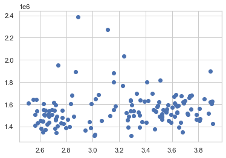

```
0.12459158039045629
```

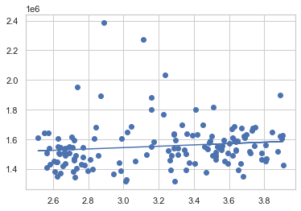

```python
#Fuel_price-cost of fuel in the region
#CPI-prevailing consumer price index
#unempoyment- prevailing unemployment rate

x = df1['Fuel_Price']
y = df1['Weekly_Sales']
plt.scatter(x,y)
plt.show()

slope, intercept, r, p, std_err = stats.linregress(x,y)
print(r) # r should be between -1 to 1

def myfunc(x):
    return slope * x + intercept

mymodel = list(map(myfunc, x))

plt.scatter(x,y)
plt.plot(x, mymodel)
plt.show()
```

Hypothesize if CPI, Unemployment, and fuel price have any prices on sales

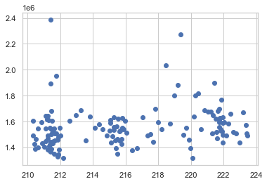

```
0.22540765942904442
```

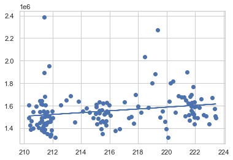

```python
x = df1['CPI']
y = df1['Weekly_Sales']

plt.scatter(x,y)
plt.show()

slope, intercept, r, p, std_err = stats.linregress(x,y)
print(r) # r should be between -1 to 1

def myfunc(x):
    return slope * x + intercept

mymodel = list(map(myfunc, x))

plt.scatter(x,y)
plt.plot(x, mymodel)
plt.show()
```

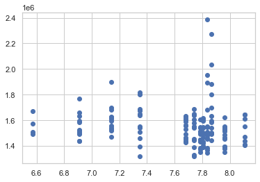

```
-0.09795539472957951
```

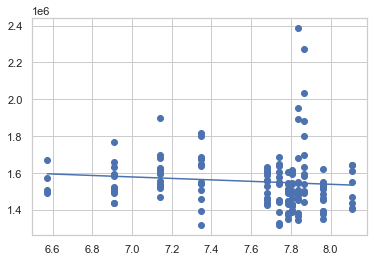

```python
x = df1['Unemployment']
y = df1['Weekly_Sales']

plt.scatter(x,y)
plt.show()

slope, intercept, r, p, std_err = stats.linregress(x,y)
print(r) # r should be between -1 to 1

def myfunc(x):
    return slope * x + intercept

mymodel = list(map(myfunc, x))
plt.scatter(x,y)
plt.plot(x, mymodel)
```

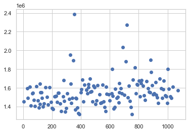

```
0.21768075944264673
```

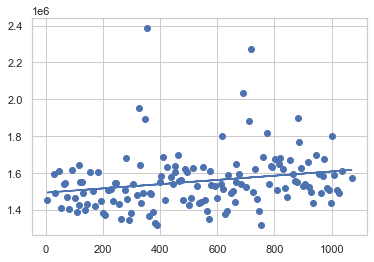

```python
x=df1['exp_day']
y=df1['Weekly_Sales']

plt.scatter(x,y)
plt.show()

slope,intercept, r, p, std_err = stats.linregress(x,y)
print(r) #r should be between -1 to 1

def myfunc(x):
    return slope * x + intercept

mymodel = list(map(myfunc, x))

plt.scatter(x,y)
plt.plot(x, mymodel)
plt.show()
```

```python
x = df1[['CPI','Unemployment','exp_day']]
y = df1['Weekly_Sales']
```

```python
from sklearn.model_selection import train_test_split
x_train, x_test, y_train, y_test = train_test_split(x, y, test_size=0.2, random_state=0)
```

```python
from sklearn.linear_model import LinearRegression
regressor = LinearRegression()
regressor.fit(x_train, y_train)
```

```
LinearRegression()
```

```python
y_pred = regressor.predict(x_test)
```

```python
predicteddf = pd.DataFrame({"Actual": y_test, "predicted": y_pred})
predicteddf
```

|  | Actual | predicted |
| --- | --- | --- |
| 45 | 1891034.93 | 1.505937e+06 |
| 118 | 1611096.05 | 1.583746e+06 |
| 16 | 1432069.95 | 1.490733e+06 |
| 56 | 1636263.41 | 1.528677e+06 |
| 22 | 1546074.18 | 1.494492e+06 |
| 7 | 1404429.92 | 1.517969e+06 |
| 108 | 1688420.76 | 1.583840e+06 |
| 134 | 1582083.40 | 1.566498e+06 |
| 130 | 1631135.79 | 1.556742e+06 |
| 101 | 1459601.17 | 1.571989e+06 |
| 94 | 2033320.66 | 1.602110e+06 |
| 127 | 1527014.04 | 1.560477e+06 |
| 8 | 1594968.28 | 1.486249e+06 |
| 96 | 1799682.38 | 1.605542e+06 |
| 140 | 1573072.81 | 1.551027e+06 |
| 33 | 1351791.03 | 1.500753e+06 |
| 84 | 1514259.78 | 1.580446e+06 |
| 120 | 1555444.55 | 1.578760e+06 |
| 119 | 1595901.87 | 1.578511e+06 |
| 24 | 1385065.20 | 1.494513e+06 |
| 63 | 1564819.81 | 1.542834e+06 |
| 86 | 1394561.83 | 1.588727e+06 |
| 60 | 1495064.75 | 1.532113e+06 |
| 26 | 1605491.78 | 1.496237e+06 |
| 62 | 1559889.00 | 1.540645e+06 |
| 18 | 1542561.09 | 1.502428e+06 |
| 113 | 1899676.88 | 1.575457e+06 |
| 106 | 1819870.00 | 1.579342e+06 |
| 44 | 1682614.26 | 1.504549e+06 |

```python
coeff_df= pd.DataFrame(regressor.coef_, x.columns, columns=['coefficent'])
coeff_df
```

|  | coefficent |
| --- | --- |
| CPI | 11704.068015 |
| Unemployment | 93350.098776 |
| exp_day | 31.781348 |

```python
from sklearn import metrics
print("Mean Absolute Error:", metrics.mean_absolute_error(y_test, y_pred))
print("Mean Squred Error:", metrics.mean_squared_error(y_test, y_pred))
print("Root Mean Squared Error:", np.sqrt(metrics.mean_squared_error(y_test, y_pred)))
```

```
Mean Absolute Error: 116216.95169902037
Mean Squred Error: 25295466668.184593
Root Mean Squared Error: 159045.48616098665
```

```python
experiment_day_start=5
df1['Date'] = pd.to_datetime(df1['Date'], dayfirst=True)
df1['exp_day'] = (df1['Date']-df1['Date'].min()).dt.days + experiment_day_start
```

```python
df.head()
```

|  | Store | Date | Weekly_Sales | Holiday_Flag | Temperature | Fuel_Price | CPI | Unemployment | year | month | semester |
| --- | --- | --- | --- | --- | --- | --- | --- | --- | --- | --- | --- |
| 0 | 1 | 2010-05-02 | 1643690.90 | 0 | 42.31 | 2.572 | 211.096358 | 8.106 | 2010 | 5 | 1 |
| 1 | 1 | 2010-12-02 | 1641957.44 | 1 | 38.51 | 2.548 | 211.242170 | 8.106 | 2010 | 12 | 2 |
| 2 | 1 | 2010-02-19 | 1611968.17 | 0 | 39.93 | 2.514 | 211.289143 | 8.106 | 2010 | 2 | 1 |
| 3 | 1 | 2010-02-26 | 1409727.59 | 0 | 46.63 | 2.561 | 211.319643 | 8.106 | 2010 | 2 | 1 |
| 4 | 1 | 2010-05-03 | 1554806.68 | 0 | 46.50 | 2.625 | 211.350143 | 8.106 | 2010 | 5 | 1 |